# Problem Set 5

Clinton Tepper

## Problem 1

The following helper functions are used in both problems 1 and 2, and serve to create bootstrap and sample helper distributions

```r
#Creates a bootstrap distribution from a population distribution given an
#arbitrary sample statistic (1 arg)
#In: population data, a stat function (1 arg), number of samples per draw, number of draws
#Out: a vector of bootstraps
boot.bootStrapper = function(popSet, statFunc, samplesPerDraw, numDraws) {

    return(matrix(sapply(1:numDraws,
    function(x) statFunc(sample(popSet, samplesPerDraw, replace = TRUE))),
    numDraws));
}

#Creates a sample distribution from a population function given an
#arbitrary sample statistic (1 arg)
#In: population fucntion (1 arg which takes in number of samples per draw), a stat function (1 arg),
# number of samples per draw, number of draws
#Out: a vector of sample calculations
boot.sampleDist = function(popFunc, statFunc, samplesPerDraw, numDraws) {
    return(matrix(sapply(rep(samplesPerDraw, numDraws), function(x) statFunc(popFunc(x))), numDraws));
}
```

Having defined our helper functions, we now simulate population and bootstrap histograms for $e^{avg(X)}$ where X is a vector of 100 RVs~N(5,1).

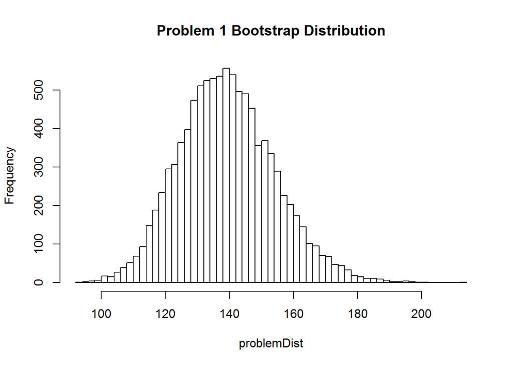

```r
population = 100;
draws = 10000;
popGen = function(x) rnorm(x, 5, 1);
#define the statistic and population generator function
statGen = function(x) exp(mean(x));

dataSet = popGen(population);
#acquire the data set
popStat = statGen(dataSet);
problemDist = boot.bootStrapper(dataSet, statGen, population, draws);
hist(problemDist, 50, main = "Problem 1 Bootstrap Distribution");
```

```r
cat("\nThe problem 1 standard error is:\n");
```

```
##
## The problem 1 standard error is:
```

```r
cat(var(problemDist) ^ .5);
```

```
## 14.82559
```

```r
cat("\n\nThe pivotal confidence interval is:\n")
```

```
##
##
## The pivotal confidence interval is:
```

```r
CIPivotal = c(2 * popStat - quantile(problemDist, .025), 2 * popStat - quantile(problemDist, .975));
cat(CIPivotal);
```

```
## 164.1922 106.0769
```

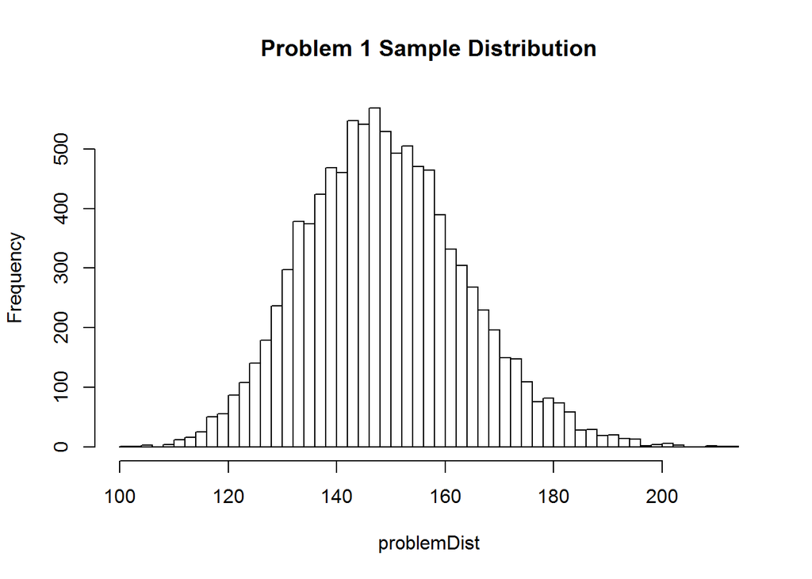

```r
problemDist = boot.sampleDist(popGen, statGen, population, draws)
hist(problemDist, 50, main = "Problem 1 Sample Distribution");
```

We conclude by noting that the bootstrap historgram seems reasonably close to the population histogram.

## Problem 2

### Part a

The following block of code uses the same helper functions as problem 1 to generate both a population and a sample distribution for the max of 50 uniform distribution samples

```r
population = 50;
popGen = function(x) runif(x);
#define the statistic and population generator function
statGen = function(x) max(x);

dataSet = popGen(population);
#acquire the data set
popStat = statGen(dataSet);
problemDist = boot.bootStrapper(dataSet, statGen, population, draws);
CIPivotal = c(2 * popStat - quantile(problemDist, .025), 2 * popStat - quantile(problemDist, .975));

cat("\n\nThe problem 2 standard error is:\n");
```

```
##
##
## The problem 2 standard error is:
```

```r
cat(var(problemDist) ^ .5);
```

```
## 0.04138055
```

```r
cat("\n\nThe pivotal confidence interval is:\n")
```

```
##
##
## The pivotal confidence interval is:
```

```r
cat(CIPivotal);
```

```
## 1.091824 0.9997657
```

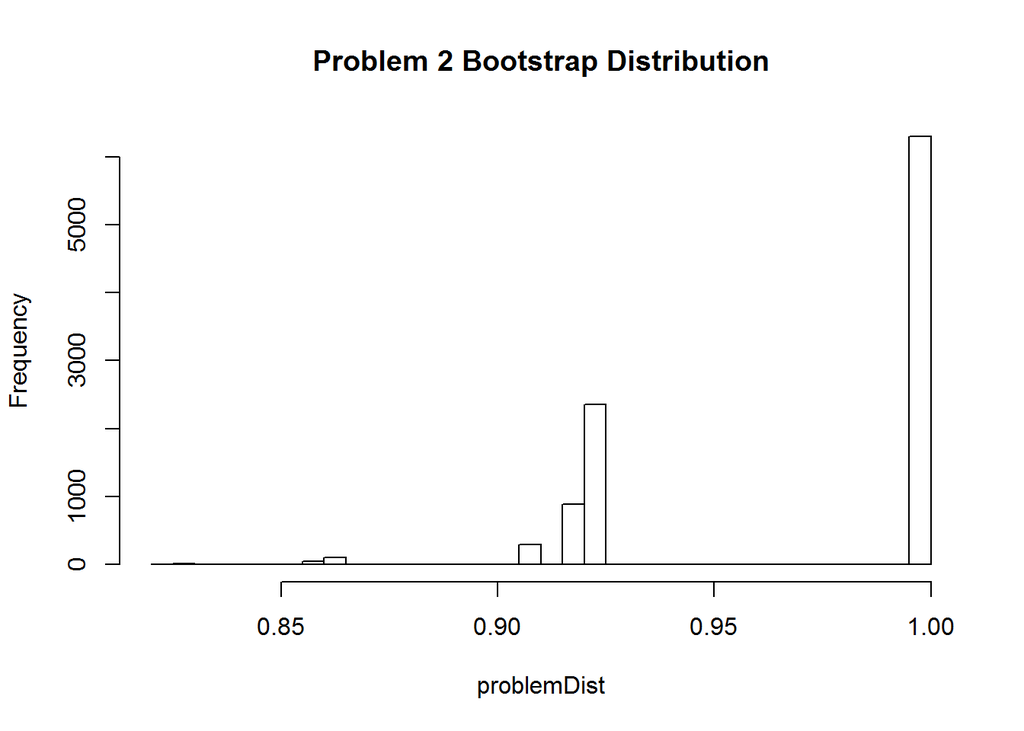

```r
hist(problemDist, 50, main = "Problem 2 Bootstrap Distribution");
```

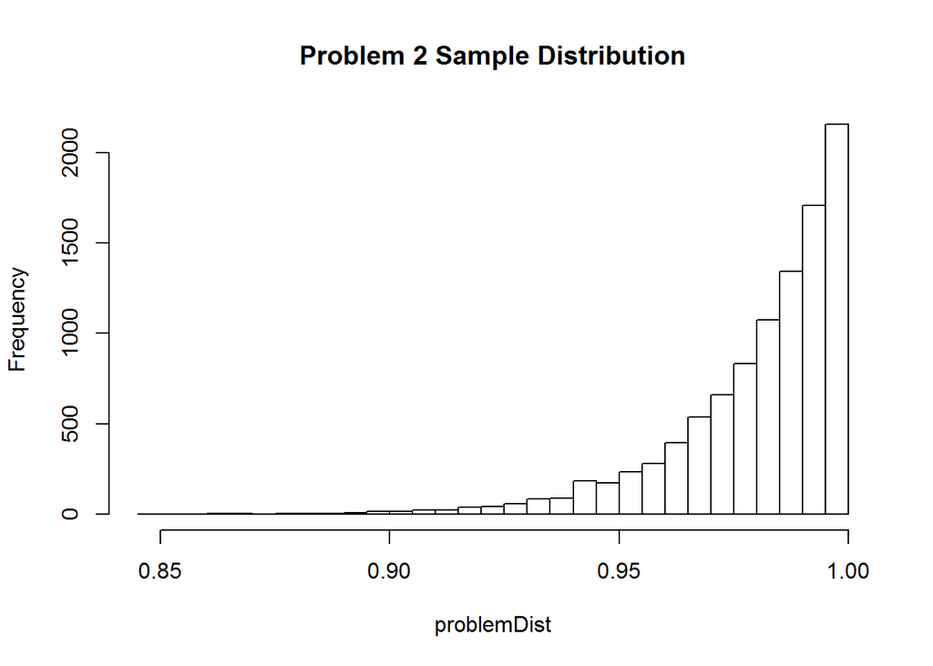

```r
problemDist = boot.sampleDist(popGen, statGen, population, draws)
hist(problemDist, 50, main = "Problem 2 Sample Distribution");
```

We note that the bootstrap approximation is lacking in this case.

### Part b

The probability that $\hat{\theta}_{a}=\hat{\theta}_{b}$ is equal to zero because $\hat{\theta}$ is a continuous random variable with a range of $[0,1]$. On the other hand, the probability that $\hat{\theta}^{*}$ is equal to $\hat{\theta}$ is equal to the probability that $\hat{\theta}\in\hat{F}$ where $\hat{F}$ is the bootstrap sample. This directly results the calculation for $\hat{\theta}=max\left(\hat{F}\right)$. The probability that $\hat{\theta}\in\hat{F}$ is equal to $1-\left(1-1/n\right)^{n}$. Then:

$$\begin{align*}
\lim_{n\to\infty}1-\left(1-1/n\right)^{n}= & 1-\lim_{n\to\infty}\left(1-1/n\right)^{n}\\
ln\left(\lim_{n\to\infty}\left(1-1/n\right)^{n}\right)= & \lim_{n\to\infty}nln\left(1-1/n\right)\\
ln\left(\lim_{n\to\infty}\left(1-1/n\right)^{n}\right)= & \lim_{n\to\infty}\frac{\frac{1/n^{2}}{1-1/n}}{-1/n^{2}}\text{ (by L'Hopital's Rule)}\\
ln\left(\lim_{n\to\infty}\left(1-1/n\right)^{n}\right)= & \lim_{n\to\infty}\frac{-1}{1-1/n}=-1\\
\lim_{n\to\infty}\left(1-1/n\right)^{n}= & \frac{1}{e}\\
\lim_{n\to\infty}1-\left(1-1/n\right)^{n}= & 1-\frac{1}{e}=.632
\end{align*}$$

## Problem 3

### Part a

Walking down the moments and solving the system of equations

$$\begin{align*}
a_{1}=\frac{1}{b-a}\int_{a}^{b}xdx=\frac{b^{2}-a^{2}}{b-a}=\frac{a+b}{2}= & \frac{1}{n}\sum_{j=1}^{n}X_{i}=\overline{X}\\
a_{2}=\frac{1}{b-a}\int_{a}^{b}x^{2}dx=\frac{b^{3}-a^{3}}{3\left(b-a\right)}=\frac{a^{2}+ab+b^{2}}{3}= & \frac{1}{n}\sum_{j=1}^{n}X_{i}^{2}\\
\frac{1}{n}\sum_{j=1}^{n}X_{i}^{2} & =\frac{\left(2\overline{X}-b\right)^{2}+\left(2\overline{X}-b\right)b+b^{2}}{3}\\
\frac{1}{n}\sum_{j=1}^{n}X_{i}^{2} & =\frac{4\overline{X}^{2}-4\overline{X}b+b^{2}+2\overline{X}b-b^{2}+b^{2}}{3}\\
\frac{1}{n}\sum_{j=1}^{n}X_{i}^{2} & =\frac{4\overline{X}^{2}-2\overline{X}b+b^{2}}{3}\\
0= & 4\overline{X}^{2}-\frac{3}{n}\sum_{j=1}^{n}X_{i}^{2}-2\overline{X}b+b^{2}\\
\text{then: }b= & \frac{-\beta+\sqrt{\beta^{2}-4\delta}}{2}\\
s.t.\\
\beta= & -2\overline{X}\\
\delta= & 4\overline{X}^{2}-\frac{3}{n}\sum_{j=1}^{n}X_{i}^{2}\\
\frac{a+b}{2}= & \overline{X}\\
a= & 2\overline{X}-b\\
a= & \frac{-\beta-\sqrt{\beta^{2}-4\delta}}{2}
\end{align*}$$

### Part b

- Let $X_{-}$ denote $min{ X_{1…n}} $ and $X_{+}=max{ X_{1…n}} $. Then we know that the probability that $L_{n}(a)$ and $L_{n}(b)$ is between $X_{-}$ and $X_{+}$ is equal to zero. In other words, we know that $L_{n}(a)\le X_{-}$ and $X_{+}\le L_{n}(b)$.
- From the definition of the uniform distribution, we know the likelihood of any single point outside of these boundaries is $\frac{1}{b-a}\text{ such that }\left\{ a,b\right\} \notin(X_{-},X_{+})$ and zero otherwise. Therefore the likelihood estimator is $L=\frac{1}{\left(b-a\right)^{n}}$
- Because the function $\frac{1}{\left(b-a\right)^{n}}$ is strictly decreasing in b and strictly increasing in a, it follows $b=X_{+}$ and $a=X_{-}$.

### Part c

Note that:

$$\begin{align*}
\tau= & \frac{1}{b-a}\int_{a}^{b}xdF\\
\tau= & \frac{b^{2}-a^{2}}{2\left(b-a\right)}=\frac{a+b}{2}
\end{align*}$$

Therefore by equivariance, we know that the MLE for $\tau$ is:

$$\begin{align*}
\tau= & \frac{X_{-}+X_{+}}{2}
\end{align*}$$

## Problem 4

- We must prove that $\hat{\theta}\stackrel{p}{\to}\theta$. Therefore we must prove that $p\left(\epsilon<\left|\theta-\hat{\theta}\right|\right)\to0$ for all $\epsilon>0$. Note that because $p(\theta-\hat{\theta}<-\epsilon)=0$, we can write the objective as $p\left(\epsilon<\theta-\hat{\theta}\right)\to0$ .
- For $\epsilon\ge\theta$, we know $p(\epsilon<\theta-\hat{\theta})$ equals zero.
- The estimator is $\hat{\theta}=max\left(\left\{ X_{n}\right\} \right)$. As discussed in the problem hint, $P\left(\hat{\theta}\le c\right)=P\left(\prod_{j=1}^{n}\left(X_{j}<c\right)\right)$. For $\epsilon<\theta$, the probability for n=1 that $p(\epsilon<\theta-\hat{\theta_{1}})=\frac{\theta-\epsilon}{\theta}$. Similarly, $p(\epsilon<\theta-\hat{\theta_{n}})=\left(\frac{\theta-\epsilon}{\theta}\right)^{n}$. Moreover, $\lim_{n\to\infty}\left(\frac{\theta-\epsilon}{\theta}\right)^{n}=0$.
- Therefore $p\left(\epsilon<\left|\theta-\hat{\theta}\right|\right)\to0$.

## Problem 5

### Part a

Because the values are censored (as opposed to truncated) the likelihood for any $y>c$ will be the same as the standard regression model, or $\frac{1}{\sqrt{2\phi\sigma^{2}}}exp\left(\frac{-\left(y-X\beta\right)^{t}\left(y-X\beta\right)}{2\sigma^{2}}\right)$. Our model is making the further assumption that any value $y_{i}^{*}\le c$ corresponds to $y_{i}=c$. Therefore for values of y that are less than zero, the likelihood function takes a discrete form, which by the normalization requirement must consist of the residual probability mass. Therefore:

$$\begin{align*}
L(\beta,\sigma^{2})= & \prod_{j=1}^{n}Q_{i}\\
Q_{i}= & \begin{cases}
\frac{1}{\sqrt{2\pi\sigma^{2}}}exp\left(\frac{-\left(y_{i}-\beta x_{i}\right)^{2}}{2\sigma^{2}}\right) & y_{i}>c\\
\Phi\left(\frac{c-\beta x_{i}}{\sigma}\right) & y_{i}\le c
\end{cases}
\end{align*}$$

In this case where $c=0$ we get:

$$\begin{align*}
Q_{i}= & \begin{cases}
\frac{1}{\sqrt{2\pi\sigma^{2}}}exp\left(\frac{-\left(y_{i}-\beta x_{i}\right)^{2}}{2\sigma^{2}}\right) & y_{i}>0\\
1-\Phi\left(\frac{\beta x_{i}}{\sigma}\right) & y_{i}\le0
\end{cases}
\end{align*}$$

### Part b

The following code uses a helper function to calculate the maximum (log) likelihood of the truncated regression function. The results are displayed via a contour plot for different levels of sigma and beta.

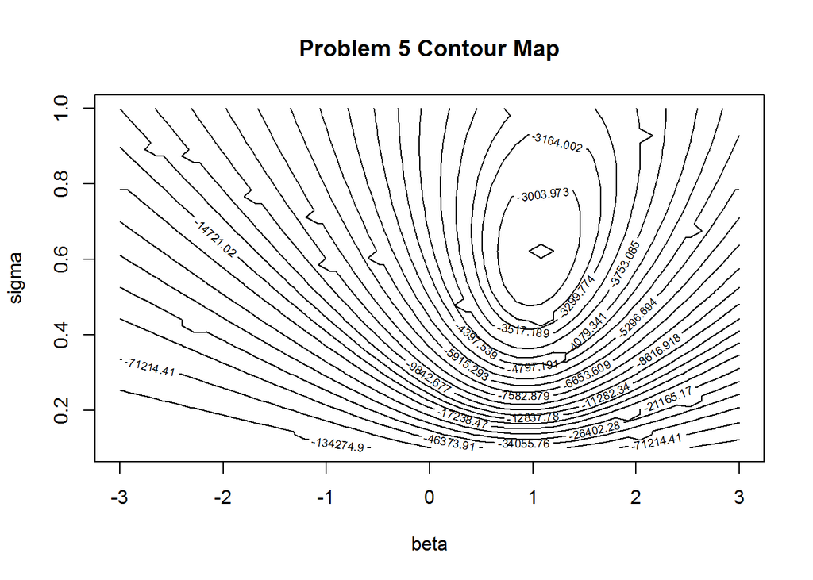

```r
tobitLike = function(beta, sigma, cutoff, xVec, yVec) {
    minLike = -10 ^ 8;
    #minimum likelihood to prevent -inf results
    singleLike = function(x, y)
        log(if (y > cutoff) dnorm(y - beta * x, 0, sigma) else pnorm(cutoff - beta * x, 0, sigma));
        #print(mapply(singleLike, xVec, yVec));
    return(max(sum(mapply(singleLike, xVec, yVec)), minLike));
}

########################Problem 5 Script entry point############################
numVals = 4000;
#Define the parameters
edgeSize = 50;
sigmaMin = 0.1;
sigmaMax = 1;
betaMin = -3;
betaMax = 3;

#true population parameters
betaPop = 1;
sigmaPop = 0.6;

xSeq = seq(betaMin, betaMax, (betaMax - betaMin) / edgeSize);
#establish the parameter grid
ySeq = seq(sigmaMin, sigmaMax, (sigmaMax - sigmaMin) / edgeSize);
sigBetaGrid = data.matrix(expand.grid(xSeq, ySeq));
#establish the parameter grid

xVector = runif(numVals, -1, 1);
yVector = mapply(function(x, e) max(betaPop * x + sigmaPop * e, 0), xVector, rnorm(numVals));

likelihoods = mapply(function(b, s) tobitLike(b, s, 0, xVector, yVector), #pass the appropriate parameters to tobitlike
    sigBetaGrid[, 1], sigBetaGrid[, 2]);
likeLevels = quantile(likelihoods, seq(0, 1, .04));
#print(likelihoods);
contour(xSeq, ySeq, matrix(likelihoods, length(xSeq), length(ySeq)), levels = likeLevels,
main = "Problem 5 Contour Map", xlab = "beta", ylab = "sigma");
```

Note that the contour map indicates the highest likelihood estimates for beta and sigma are at beta=1 and sigma=0.6 (indicated by the inner-most circle), a result consistent with the true population parameters.